# Las bases de los pronósticos

### Intervalos de predicción con residuales bootstrap

Cuando no es razonable asumir **normalidad** en los residuos, podemos aplicarles *bootstraping*, ya que esto solo asume la no autocorrelación.

Teníamos que los residuos se calculan $e_{t}=y_{t}-\hat{y}_{t | t-1}$. Reescribiendo, tenemos que:

$$y_{t}=\hat{y}_{t | t-1}+e_{t}$$
y podemos simular la siguiente observación de una serie de tiempo con:

$$y_{T+1}=\hat{y}_{T+1 | T}+e_{T+1}$$

donde $\hat{y}_{T+1} | T$ es el pronóstico de un periodo (one-step) y $e_{T+1}$ es el error futuro (que desconocemos). Ya que no están autocorelacionados los errores, y puesto que asumimos que los errores futuros serán similares a los históricos, podemos cambiar $e_{T+1}$ al hacer un muestreo de los residuos. Podemos realizar el mismo proceso para $y_{T+2}, y_{T+3}, \dots$.

Si realizamos esto varias veces, obtendremos muchos escenarios futuros posibles. Para ver algunos de ellos, utilizamos `generate`.

[figure not shown]

```r
fit <- google_2015 %>%
  model(NAIVE(Close))

sim <- fit %>%  generate(h = 30, times = 5, bootstrap = TRUE, seed = 123) # only works with dev version

sim
```

| Symbol | .model | day | .rep | .sim |
| --- | --- | --- | --- | --- |
| GOOG | NAIVE(Close) | 505 | 1 | 743.8660 |
| GOOG | NAIVE(Close) | 506 | 1 | 747.3820 |
| GOOG | NAIVE(Close) | 507 | 1 | 732.7880 |
| GOOG | NAIVE(Close) | 508 | 1 | 737.3736 |
| GOOG | NAIVE(Close) | 509 | 1 | 739.4896 |
| GOOG | NAIVE(Close) | 510 | 1 | 732.9956 |
| GOOG | NAIVE(Close) | 511 | 1 | 728.4017 |
| GOOG | NAIVE(Close) | 512 | 1 | 729.7477 |
| GOOG | NAIVE(Close) | 513 | 1 | 721.2005 |
| GOOG | NAIVE(Close) | 514 | 1 | 712.5965 |

[output cut: 140 more lines]

Lo que hicimos fue generar 5 escenarios futuros posibles (`times = 5`) para los siguientes 30 días de trading (`h = 30`). Si graficamos esto, tenemos:

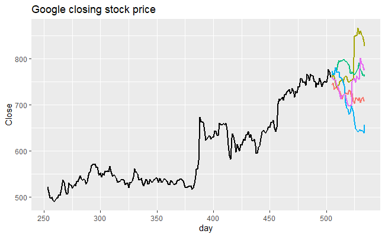

```r
google_2015 %>%
  ggplot(aes(x = day)) +
  geom_line(aes(y = Close), size = 1) +
  geom_line(aes(y = .sim, colour = as.factor(.rep)), data = sim, size = 1) +
  ggtitle("Google closing stock price") +
  guides(col = FALSE)
```

Con esto, podemos obtener intervalos de predicción, al calcular los percentiles de los escenarios futuros. El resultado se llama **intervalo de predicción bootstrapped**. Esto se puede lograr fácilmente con `forecast`.

```r
fc <- fit %>% forecast(h = 30, bootstrap = TRUE)
fc
```

| Symbol | .model | day | Close | .mean |
| --- | --- | --- | --- | --- |
| GOOG | NAIVE(Close) | 505 |  | 759.0083 |
| GOOG | NAIVE(Close) | 506 |  | 759.1667 |
| GOOG | NAIVE(Close) | 507 |  | 759.0987 |
| GOOG | NAIVE(Close) | 508 |  | 759.2067 |
| GOOG | NAIVE(Close) | 509 |  | 759.1657 |
| GOOG | NAIVE(Close) | 510 |  | 759.0666 |
| GOOG | NAIVE(Close) | 511 |  | 759.0890 |
| GOOG | NAIVE(Close) | 512 |  | 759.1212 |
| GOOG | NAIVE(Close) | 513 |  | 759.0515 |
| GOOG | NAIVE(Close) | 514 |  | 758.9718 |

[output cut: 20 more lines]

Graficando:

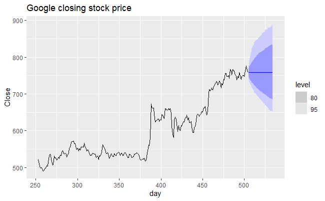

```r
fc %>% autoplot(google_2015) +
  ggtitle("Google closing stock price")
```

# Tarea

1. Conseguir datos históricos sobre dos series de tiempo.
2. Seguir los pasos del flujo de trabajo de pronóstico.
3. Estimar los modelos de referencia (*benchmark*) que consideren adecuados para su serie.
4. Realicen el diagnóstico de residuales e interpreten los resultados.
5. Ejecuten un pronóstico (ustedes deciden el horizonte de pronóstico) y definan si utilizar el método bootstrap o no y justifiquen su decisión.

# Pronósticos con transformaciones

¿Qué sucede cuando realizamos pronósticos de series a las que les hicimos alguna transformación? Por ejemplo, si los contratan para pronosticar las ventas de cubrebocas en la farmacia y ustedes hubieran realizado una transformación logarítmica de los datos, ¿cómo se realiza el pronóstico?

Cuando se realiza una transformación matemática, el pronóstico se hace con esa serie transformada, y posteriormente tenemos que darle *reversa* a la transformación (*back-transformation*), para obtener pronósticos en la escala original de la serie.

La transformación inversa de Box-Cox está dada por:

$$y_{t}=\left\{\begin{array}{ll}
\exp \left(w_{t}\right) & \text { si } \lambda=0 \\
\left(\lambda w_{t}+1\right)^{1 / \lambda} & \text { en otro caso }
\end{array}\right.$$

La paquetería `fable` convenientemente realiza la transformación inversa en automático, cuando se especifica en la definición del modelo.

### Intervalos de predicción con transformaciones

El intervalo de predicción de una serie transformada se calcula, primeramente, en la escala transformada, y posteriormente se hace la transformación inversa a la escala original. Hacer esto mantiene los porcentajes de cobertura de probabilidad originales, pero el resultado ya no es simétrico alrededor de la estimación puntual.

Es importante mencionar que las transformaciones tienen muy poco efecto en la estimación puntual, pero pueden llegar a tener un gran impacto en los intervalos de predicción.

### Ajustes por sesgo

Un problema al realizar transformaciones matemáticas, como Box-Cox es que la estimaciones puntuales re transformadas ya no representan la **media** de la distribución de predicción, sino que representan ahora la **mediana**. En muchos casos puede no ser tan grave esto, pero en ocasiones el pronóstico promedio es requerido:

- *P. ej., si quieren realizar el pronóstico de la venta de cubrebocas en las farmacias de la ZMG, para, al sumarlos, obtener el pronóstico de las ventas totales de cubrebocas en ZMG. La suma de las medias da como resultado el total, pero la suma de medianas no.*

La transformación inversa de la media, para Box-Cox es:

$$y_{t}=\left\{\begin{array}{ll}
\exp \left(w_{t}\right)\left[1+\frac{\sigma_{h}^{2}}{2}\right] & \text { si } \lambda=0 \\
\left(\lambda w_{t}+1\right)^{1 / \lambda}\left[1+\frac{\sigma_{h}^{2}(1-\lambda)}{2\left(\lambda w_{t}+1\right)^{2}}\right] & \text { en otro caso }
\end{array}\right.$$
donde $\sigma_{h}^{2}$ es la varianza del pronóstico en el horizonte-$h$ en la escala transformada. Entre más grande sea la varianza, mayor será la diferencia entre la media y la mediana. A esto se le conoce como la estimación **ajustada por sesgo**.

Veamos un ejemplo sobre el pronóstico del precio promedio del huevo.

```r
eggs <- as_tsibble(fma::eggs)
fit <- eggs %>% model(RW(log(value) ~ drift()))
fc <- fit %>% forecast(h=50) %>%
  mutate(Forecast = "Bias adjusted")
fc_biased <- fit %>% forecast(h=50, bias_adjust = FALSE) %>%
  mutate(Forecast = "Simple back transformation")
```

```
The `bias_adjust` argument for forecast() has been deprecated. Please specify the desired point forecasts using `point_forecast`.
Bias adjusted forecasts are forecast means (`point_forecast = 'mean'`), non-adjusted forecasts are medians (`point_forecast = 'median'`)
```

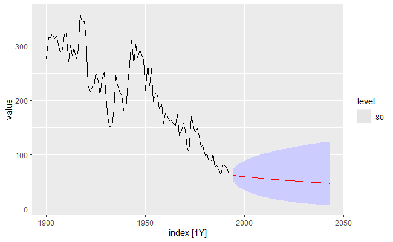

```r
eggs %>% autoplot(value) +
  autolayer(fc_biased, level = 80) +
  autolayer(fc, colour = "red", level = NULL)
```

La línea azul representa el pronóstico sesgado, mientras que la línea roja muestra el pronóstico corregido por el sesgo. `fable` en automático nos produce pronósticos ajustados por sesgo. Como se ve en el código, para generar pronósticos sesgados, tenemos que especificarlo mediante `bias_adjust = FALSE`.

# Pronósticos con descomposición

La descomposición de series de tiempo puede ser útil para producir pronósticos. Reescribiendo las fórmulas de descomposición aditiva y multiplicativa:

$$y_{t}=\hat{S}_{t}+\hat{A}_{t}$$

donde $\hat{A}_{t}$ es la serie desestacionalizada ( $\hat{A}_{t} = \hat{T}_{t} + \hat{R}_{t}$).

$$y_{t}=\hat{S}_{t}\hat{A}_{t}$$

con $\hat{A}_{t} = \hat{T}_{t} \hat{R}_{t}$.

Así, el pronóstico se realiza en dos pasos: un pronóstico para el componente estacional, y un pronóstico separado para la serie desestacionalizada. De hecho, el pronóstico del componente estacional es simplemente el método **naïve estacional**. Para los datos desestacionalizados, podemos utilizar cualquier modelo de pronóstico que veremos más adelante.

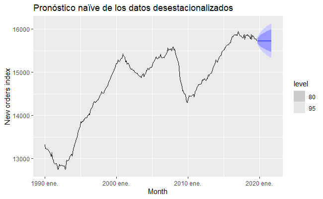

```r
us_retail_employment <- us_employment %>%
  filter(year(Month) >= 1990, Title == "Retail Trade")
dcmp <- us_retail_employment %>%
  model(STL(Employed ~ trend(window = 7), robust=TRUE)) %>%
  components() %>%
  select(-.model)
dcmp %>%
  model(NAIVE(season_adjust)) %>%
  forecast() %>%
  autoplot(dcmp) + ylab("New orders index") +
  ggtitle("Pronóstico naïve de los datos desestacionalizados")
```

A esta serie, podemos agregarle nuevamente la estacionalidad con la función `decomposition_model()`.

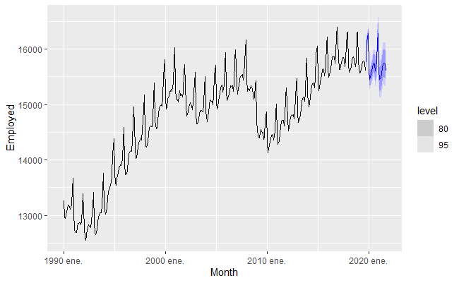

```r
us_retail_employment %>%
  model(stlf = decomposition_model(
             STL(Employed ~ trend(window = 7), robust = TRUE),
             NAIVE(season_adjust)
  )) %>%
  forecast() %>%
  autoplot(us_retail_employment)
```

# Evaluación del desempeño de los pronósticos

### Conjuntos de entrenamiento y prueba

Como hemos dicho, es muy importante separar nuestros datos en dos conjuntos: un conjunto de datos de **entrenamiento**, que son los que se utilizan para estimar el modelo, y un conjunto de datos de **prueba**, donde se evalúa el desempeño del pronóstico.

El tamaño de la prueba es, generalmente, del 20% del total de datos disponibles, aunque también puede depender del horizonte de pronóstico requerido. La prueba tiene que ser al menos tan grande como el horizonte de pronóstico más largo que se requiera (si se necesitan pronósticos para todo el siguiente año, la prueba tiene que ser del tamaño de al menos de todo el siguiente año).

**NOTA**: Es importante tener en cuenta lo siguiente:

- Un modelo que se ajusta muy bien a los datos de entrenamiento no necesariamente produce los mejores pronósticos.
- Podemos llegar a tener un ajuste perfecto del modelo a los datos, si aumentamos la cantidad de parámetros.
- Puede darse un efecto de sobre ajuste (mejor conocido como *over-fitting*) y esto es tan malo como tener un muy mal ajuste.

En alguna literatura o paqueterías pueden encontrar que al conjunto de datos de entrenamiento se les conozca como “*in-sample data*” y al conjunto de prueba “*out-of-sample data*”.

### Funciones para segmentar las series de tiempo

Hemos visto que podemos utilizar la función `filter` para filtrar una base de datos o una serie de tiempo.

```r
aus_production
```

| Quarter | Beer | Tobacco | Bricks | Cement | Electricity | Gas |
| --- | --- | --- | --- | --- | --- | --- |
| 1956 Q1 | 284 | 5225 | 189 | 465 | 3923 | 5 |
| 1956 Q2 | 213 | 5178 | 204 | 532 | 4436 | 6 |
| 1956 Q3 | 227 | 5297 | 208 | 561 | 4806 | 7 |
| 1956 Q4 | 308 | 5681 | 197 | 570 | 4418 | 6 |
| 1957 Q1 | 262 | 5577 | 187 | 529 | 4339 | 5 |
| 1957 Q2 | 228 | 5651 | 214 | 604 | 4811 | 7 |
| 1957 Q3 | 236 | 5317 | 227 | 603 | 5259 | 7 |
| 1957 Q4 | 320 | 6152 | 222 | 582 | 4735 | 6 |
| 1958 Q1 | 272 | 5758 | 199 | 554 | 4608 | 5 |
| 1958 Q2 | 233 | 5641 | 229 | 620 | 5196 | 7 |

[output cut: 208 more lines]

Por ejemplo, tomando la producción en Australia, podemos filtrar para tener los datos a partir de 1995:

```r
aus_production %>% filter(year(Quarter) >= 1995)
```

| Quarter | Beer | Tobacco | Bricks | Cement | Electricity | Gas |
| --- | --- | --- | --- | --- | --- | --- |
| 1995 Q1 | 426 | 4714 | 430 | 1626 | 41768 | 131 |
| 1995 Q2 | 408 | 3939 | 457 | 1703 | 43686 | 167 |
| 1995 Q3 | 416 | 6137 | 417 | 1733 | 46022 | 181 |
| 1995 Q4 | 520 | 4739 | 370 | 1545 | 42800 | 145 |
| 1996 Q1 | 409 | 4275 | 310 | 1526 | 43661 | 133 |
| 1996 Q2 | 398 | 5239 | 358 | 1593 | 44707 | 162 |
| 1996 Q3 | 398 | 6293 | 379 | 1706 | 46326 | 184 |
| 1996 Q4 | 507 | 5575 | 369 | 1699 | 43346 | 146 |
| 1997 Q1 | 432 | 4802 | 330 | 1511 | 43938 | 135 |
| 1997 Q2 | 398 | 5523 | 390 | 1785 | 45828 | 171 |

[output cut: 52 more lines]

o para obtener los datos de una cierta estación:

```r
aus_production %>% filter(quarter(Quarter) == 1)
```

| Quarter | Beer | Tobacco | Bricks | Cement | Electricity | Gas |
| --- | --- | --- | --- | --- | --- | --- |
| 1956 Q1 | 284 | 5225 | 189 | 465 | 3923 | 5 |
| 1957 Q1 | 262 | 5577 | 187 | 529 | 4339 | 5 |
| 1958 Q1 | 272 | 5758 | 199 | 554 | 4608 | 5 |
| 1959 Q1 | 261 | 5478 | 208 | 573 | 4883 | 5 |
| 1960 Q1 | 286 | 5980 | 242 | 621 | 5387 | 6 |
| 1961 Q1 | 295 | 6022 | 241 | 688 | 5709 | 6 |
| 1962 Q1 | 279 | 6072 | 229 | 637 | 6098 | 6 |
| 1963 Q1 | 294 | 6051 | 231 | 674 | 6707 | 6 |
| 1964 Q1 | 313 | 5890 | 293 | 797 | 7469 | 6 |
| 1965 Q1 | 331 | 6201 | 309 | 902 | 8170 | 6 |

[output cut: 45 more lines]

Otra función útil para filtrar o segmentar series de tiempo es `slice()`, que utiliza el índice para filtrar los datos.

```r
aus_production %>%
  slice(n()-19:0)
```

| Quarter | Beer | Tobacco | Bricks | Cement | Electricity | Gas |
| --- | --- | --- | --- | --- | --- | --- |
| 2005 Q3 | 408 | NA | NA | 2340 | 56043 | 221 |
| 2005 Q4 | 482 | NA | NA | 2265 | 54992 | 180 |
| 2006 Q1 | 438 | NA | NA | 2027 | 57112 | 171 |
| 2006 Q2 | 386 | NA | NA | 2278 | 57157 | 224 |
| 2006 Q3 | 405 | NA | NA | 2427 | 58400 | 233 |
| 2006 Q4 | 491 | NA | NA | 2451 | 56249 | 192 |
| 2007 Q1 | 427 | NA | NA | 2140 | 56244 | 187 |
| 2007 Q2 | 383 | NA | NA | 2362 | 55036 | 234 |
| 2007 Q3 | 394 | NA | NA | 2536 | 59806 | 245 |
| 2007 Q4 | 473 | NA | NA | 2562 | 56411 | 205 |

[output cut: 10 more lines]

Esto filtra los últimos 20 datos (5 años).

A partir de `dplyr 1.0.0`, existen algunas variantes de `slice()` que pueden sernos bastante útiles, como `slice_head()`, `slice_tail()`, `slice_sample()`, `slice_max()`, etc.

Podemos reescribir el código de arriba para hacerlo más explícito:

```r
aus_production %>%
  slice_tail(n = 20)
```

| Quarter | Beer | Tobacco | Bricks | Cement | Electricity | Gas |
| --- | --- | --- | --- | --- | --- | --- |
| 2005 Q3 | 408 | NA | NA | 2340 | 56043 | 221 |
| 2005 Q4 | 482 | NA | NA | 2265 | 54992 | 180 |
| 2006 Q1 | 438 | NA | NA | 2027 | 57112 | 171 |
| 2006 Q2 | 386 | NA | NA | 2278 | 57157 | 224 |
| 2006 Q3 | 405 | NA | NA | 2427 | 58400 | 233 |
| 2006 Q4 | 491 | NA | NA | 2451 | 56249 | 192 |
| 2007 Q1 | 427 | NA | NA | 2140 | 56244 | 187 |
| 2007 Q2 | 383 | NA | NA | 2362 | 55036 | 234 |
| 2007 Q3 | 394 | NA | NA | 2536 | 59806 | 245 |
| 2007 Q4 | 473 | NA | NA | 2562 | 56411 | 205 |

[output cut: 10 more lines]

Podemos usar `slice` para datos agrupados:

```r
aus_retail %>%
  group_by(State, Industry) %>%
  slice(1:12)
```

| State | Industry | Series ID | Month | Turnover |
| --- | --- | --- | --- | --- |
| Australian Capital Territory | Cafes, restaurants and catering services | A3349849A | 1982 abr. | 4.4 |
| Australian Capital Territory | Cafes, restaurants and catering services | A3349849A | 1982 may. | 3.4 |
| Australian Capital Territory | Cafes, restaurants and catering services | A3349849A | 1982 jun. | 3.6 |
| Australian Capital Territory | Cafes, restaurants and catering services | A3349849A | 1982 jul. | 4.0 |
| Australian Capital Territory | Cafes, restaurants and catering services | A3349849A | 1982 ago. | 3.6 |
| Australian Capital Territory | Cafes, restaurants and catering services | A3349849A | 1982 sep. | 4.2 |
| Australian Capital Territory | Cafes, restaurants and catering services | A3349849A | 1982 oct. | 4.8 |
| Australian Capital Territory | Cafes, restaurants and catering services | A3349849A | 1982 nov. | 5.4 |
| Australian Capital Territory | Cafes, restaurants and catering services | A3349849A | 1982 dic. | 6.9 |
| Australian Capital Territory | Cafes, restaurants and catering services | A3349849A | 1983 ene. | 3.8 |

[output cut: 990 more lines]

Otra función es `top_n`, la cual nos permite obtener las `n` observaciones más extremas.

```r
gafa_stock %>%
  group_by(Symbol) %>%
  top_n(1, Close)
```

| Symbol | Date | Open | High | Low | Close | Adj_Close | Volume |
| --- | --- | --- | --- | --- | --- | --- | --- |
| AAPL | 2018-10-03 | 230.05 | 233.470 | 229.78 | 232.07 | 230.2755 | 28654800 |
| AMZN | 2018-09-04 | 2026.50 | 2050.500 | 2013.00 | 2039.51 | 2039.5100 | 5721100 |
| FB | 2018-07-25 | 215.72 | 218.620 | 214.27 | 217.50 | 217.5000 | 58954200 |
| GOOG | 2018-07-26 | 1251.00 | 1269.771 | 1249.02 | 1268.33 | 1268.3300 | 2405600 |

## Errores de pronóstico

El error de pronóstico es la diferencia entre el valor real ocurrido y el dato pronosticado.

$$e_{T+h}=y_{T+h}-\hat{y}_{T+h | T}$$

Los errores de pronóstico son distintos de los residuales en dos formas:

1. Los residuales se calculan con los datos de *entrenamiento*, mientras que los errores de pronóstico se calculan con los de *prueba*.
2. Los residuos se calculan mediante pronósticos de un paso (one-step), donde los errores de pronóstico pueden ser multi-step.

Hay muchos tipos de cálculo del error general de un modelo de pronóstico.

### Errores dependientes de la escala de los datos

Los errores de pronóstico están medidos en la misma escala de los datos originales. Hay ciertos tipos de error que solo se basan en $e_{T}$, por lo que también dependen de la escala y no pueden ser utilizados para comparar el desempeño con otra serie de tiempo que tenga otras unidades.

Los dos más utilizados en este rubro son el **MAE** y el **RMSE**.

$$\begin{aligned}
&\text { Mean absolute error: } \mathrm{MAE}=\operatorname{mean}\left(\left|e_{t}\right|\right)\\
&\text { Root mean squared error: } \operatorname{RMSE}=\sqrt{\operatorname{mean}\left(e_{t}^{2}\right)}
\end{aligned}$$

El MAE es muy utilizado debido a su facilidad de cómputo y de interpretación. Un método de pronóstico que minimiza el MAE nos dará pronósticos de la mediana de la distribución. Pronósticos que minimizan el RMSE obtienen pronósticos de la media, por lo que este método también es muy utilizado, a pesar de ser más pesado computacionalmente y complicado de interpretar.

### Errores porcentuales

Los errores porcentuales, al ser un porcentaje, no tienen unidades y son utilizados para comparar el desempeño de pronósticos de distintos conjuntos de datos. El más utilizado es el MAPE (error absoluto promedio porcentual). Si definimos al error porcentual como $p_{t}=100 e_{t} / y_{t}$

Mean absolute percentage error: **MAPE** $=\operatorname{mean}\left(\left|p_{t}\right|\right)$

La desventaja con estos errores es que se indeterminana o vuelven infinitos con valores de $y_t = 0$. Para ello, se definió el MAPE simétrico:

$$\operatorname{sMAPE}=\operatorname{mean}\left(200\left|y_{t}-\hat{y}_{t}\right| /\left(y_{t}+\hat{y}_{t}\right)\right)$$

Aunque este método no se recomienda tanto utilizarlo en la práctica.

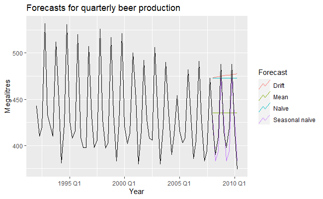

```r
recent_production <- aus_production %>% filter(year(Quarter) >= 1992)
beer_train <- recent_production %>% filter(year(Quarter) <= 2007)

beer_fit <- beer_train %>%
  model(
    Mean = MEAN(Beer),
    `Naïve` = NAIVE(Beer),
    `Seasonal naïve` = SNAIVE(Beer),
    Drift = RW(Beer ~ drift())
  )

beer_fc <- beer_fit %>%
  forecast(h = 10)

beer_fc %>%
  autoplot(recent_production, level = NULL) +
  xlab("Year") + ylab("Megalitres") +
  ggtitle("Forecasts for quarterly beer production") +
  guides(colour=guide_legend(title="Forecast"))
```

```r
accuracy(beer_fit)
```

| .model | .type | ME | RMSE | MAE | MPE | MAPE | MASE | ACF1 |
| --- | --- | --- | --- | --- | --- | --- | --- | --- |
| Mean | Training | 0.000000e+00 | 43.62858 | 35.23438 | -0.9365102 | 7.886776 | 2.463942 | -0.1091511 |
| Naïve | Training | 4.761905e-01 | 65.31511 | 54.73016 | -0.9162496 | 12.164154 | 3.827284 | -0.2409829 |
| Seasonal naïve | Training | -2.133333e+00 | 16.78193 | 14.30000 | -0.5537713 | 3.313685 | 1.000000 | -0.2876333 |
| Drift | Training | -5.414981e-15 | 65.31337 | 54.76795 | -1.0266948 | 12.178793 | 3.829927 | -0.2409829 |

```r
beer_fc %>%
  accuracy(recent_production)
```

| .model | .type | ME | RMSE | MAE | MPE | MAPE | MASE | ACF1 |
| --- | --- | --- | --- | --- | --- | --- | --- | --- |
| Drift | Test | -54.01905 | 64.90129 | 58.87619 | -13.582171 | 14.577487 | 4.1172161 | -0.07410793 |
| Mean | Test | -13.77500 | 38.44724 | 34.82500 | -3.969866 | 8.283390 | 2.4353147 | -0.06905715 |
| Naïve | Test | -51.40000 | 62.69290 | 57.40000 | -12.954916 | 14.184424 | 4.0139860 | -0.06905715 |
| Seasonal naïve | Test | 5.20000 | 14.31084 | 13.40000 | 1.147554 | 3.168503 | 0.9370629 | 0.13184068 |